# Risk Factor Analysis

## Outcome Variable

**Outcome Variable:** ever_swasted

## Predictor Variables

**Intervention Variable:** cleanck

**Adjustment Set:**

unadjusted

## Stratifying Variables

The analysis was stratified on these variable(s):

- agecat
- studyid
- country

## Data Summary

| agecat | studyid | country | cleanck | ever_swasted | n_cell | n |
| --- | --- | --- | --- | --- | --- | --- |
| 0-24 months (no birth wast) | CMC-V-BCS-2002 | INDIA | 1 | 0 | 141 | 368 |
| 0-24 months (no birth wast) | CMC-V-BCS-2002 | INDIA | 1 | 1 | 22 | 368 |
| 0-24 months (no birth wast) | CMC-V-BCS-2002 | INDIA | 0 | 0 | 172 | 368 |
| 0-24 months (no birth wast) | CMC-V-BCS-2002 | INDIA | 0 | 1 | 33 | 368 |
| 0-24 months (no birth wast) | GMS-Nepal | NEPAL | 1 | 0 | 8 | 589 |
| 0-24 months (no birth wast) | GMS-Nepal | NEPAL | 1 | 1 | 1 | 589 |
| 0-24 months (no birth wast) | GMS-Nepal | NEPAL | 0 | 0 | 460 | 589 |
| 0-24 months (no birth wast) | GMS-Nepal | NEPAL | 0 | 1 | 120 | 589 |
| 0-24 months (no birth wast) | IRC | INDIA | 1 | 0 | 179 | 399 |
| 0-24 months (no birth wast) | IRC | INDIA | 1 | 1 | 51 | 399 |
| 0-24 months (no birth wast) | IRC | INDIA | 0 | 0 | 144 | 399 |
| 0-24 months (no birth wast) | IRC | INDIA | 0 | 1 | 25 | 399 |
| 0-24 months (no birth wast) | MAL-ED | PERU | 1 | 0 | 1 | 2 |
| 0-24 months (no birth wast) | MAL-ED | PERU | 1 | 1 | 0 | 2 |
| 0-24 months (no birth wast) | MAL-ED | PERU | 0 | 0 | 1 | 2 |
| 0-24 months (no birth wast) | MAL-ED | PERU | 0 | 1 | 0 | 2 |
| 0-24 months (no birth wast) | MAL-ED | SOUTH AFRICA | 1 | 0 | 2 | 3 |
| 0-24 months (no birth wast) | MAL-ED | SOUTH AFRICA | 1 | 1 | 0 | 3 |
| 0-24 months (no birth wast) | MAL-ED | SOUTH AFRICA | 0 | 0 | 1 | 3 |
| 0-24 months (no birth wast) | MAL-ED | SOUTH AFRICA | 0 | 1 | 0 | 3 |
| 0-24 months (no birth wast) | NIH-Crypto | BANGLADESH | 1 | 0 | 352 | 575 |
| 0-24 months (no birth wast) | NIH-Crypto | BANGLADESH | 1 | 1 | 6 | 575 |
| 0-24 months (no birth wast) | NIH-Crypto | BANGLADESH | 0 | 0 | 212 | 575 |
| 0-24 months (no birth wast) | NIH-Crypto | BANGLADESH | 0 | 1 | 5 | 575 |
| 0-24 months (no birth wast) | PROVIDE | BANGLADESH | 1 | 0 | 548 | 687 |
| 0-24 months (no birth wast) | PROVIDE | BANGLADESH | 1 | 1 | 13 | 687 |
| 0-24 months (no birth wast) | PROVIDE | BANGLADESH | 0 | 0 | 120 | 687 |
| 0-24 months (no birth wast) | PROVIDE | BANGLADESH | 0 | 1 | 6 | 687 |
| 0-6 months (no birth wast) | CMC-V-BCS-2002 | INDIA | 1 | 0 | 147 | 350 |
| 0-6 months (no birth wast) | CMC-V-BCS-2002 | INDIA | 1 | 1 | 10 | 350 |
| 0-6 months (no birth wast) | CMC-V-BCS-2002 | INDIA | 0 | 0 | 173 | 350 |
| 0-6 months (no birth wast) | CMC-V-BCS-2002 | INDIA | 0 | 1 | 20 | 350 |
| 0-6 months (no birth wast) | GMS-Nepal | NEPAL | 1 | 0 | 8 | 576 |
| 0-6 months (no birth wast) | GMS-Nepal | NEPAL | 1 | 1 | 0 | 576 |
| 0-6 months (no birth wast) | GMS-Nepal | NEPAL | 0 | 0 | 539 | 576 |
| 0-6 months (no birth wast) | GMS-Nepal | NEPAL | 0 | 1 | 29 | 576 |
| 0-6 months (no birth wast) | IRC | INDIA | 1 | 0 | 179 | 381 |
| 0-6 months (no birth wast) | IRC | INDIA | 1 | 1 | 43 | 381 |
| 0-6 months (no birth wast) | IRC | INDIA | 0 | 0 | 145 | 381 |
| 0-6 months (no birth wast) | IRC | INDIA | 0 | 1 | 14 | 381 |
| 0-6 months (no birth wast) | MAL-ED | PERU | 1 | 0 | 1 | 2 |
| 0-6 months (no birth wast) | MAL-ED | PERU | 1 | 1 | 0 | 2 |
| 0-6 months (no birth wast) | MAL-ED | PERU | 0 | 0 | 1 | 2 |
| 0-6 months (no birth wast) | MAL-ED | PERU | 0 | 1 | 0 | 2 |
| 0-6 months (no birth wast) | MAL-ED | SOUTH AFRICA | 1 | 0 | 2 | 3 |
| 0-6 months (no birth wast) | MAL-ED | SOUTH AFRICA | 1 | 1 | 0 | 3 |
| 0-6 months (no birth wast) | MAL-ED | SOUTH AFRICA | 0 | 0 | 1 | 3 |
| 0-6 months (no birth wast) | MAL-ED | SOUTH AFRICA | 0 | 1 | 0 | 3 |
| 0-6 months (no birth wast) | NIH-Crypto | BANGLADESH | 1 | 0 | 355 | 572 |
| 0-6 months (no birth wast) | NIH-Crypto | BANGLADESH | 1 | 1 | 0 | 572 |
| 0-6 months (no birth wast) | NIH-Crypto | BANGLADESH | 0 | 0 | 216 | 572 |
| 0-6 months (no birth wast) | NIH-Crypto | BANGLADESH | 0 | 1 | 1 | 572 |
| 0-6 months (no birth wast) | PROVIDE | BANGLADESH | 1 | 0 | 552 | 683 |
| 0-6 months (no birth wast) | PROVIDE | BANGLADESH | 1 | 1 | 5 | 683 |
| 0-6 months (no birth wast) | PROVIDE | BANGLADESH | 0 | 0 | 125 | 683 |
| 0-6 months (no birth wast) | PROVIDE | BANGLADESH | 0 | 1 | 1 | 683 |
| 6-24 months | CMC-V-BCS-2002 | INDIA | 1 | 0 | 150 | 373 |
| 6-24 months | CMC-V-BCS-2002 | INDIA | 1 | 1 | 13 | 373 |
| 6-24 months | CMC-V-BCS-2002 | INDIA | 0 | 0 | 193 | 373 |
| 6-24 months | CMC-V-BCS-2002 | INDIA | 0 | 1 | 17 | 373 |
| 6-24 months | GMS-Nepal | NEPAL | 1 | 0 | 7 | 529 |
| 6-24 months | GMS-Nepal | NEPAL | 1 | 1 | 1 | 529 |
| 6-24 months | GMS-Nepal | NEPAL | 0 | 0 | 421 | 529 |
| 6-24 months | GMS-Nepal | NEPAL | 0 | 1 | 100 | 529 |
| 6-24 months | IRC | INDIA | 1 | 0 | 219 | 400 |
| 6-24 months | IRC | INDIA | 1 | 1 | 12 | 400 |
| 6-24 months | IRC | INDIA | 0 | 0 | 156 | 400 |
| 6-24 months | IRC | INDIA | 0 | 1 | 13 | 400 |
| 6-24 months | MAL-ED | SOUTH AFRICA | 1 | 0 | 1 | 1 |
| 6-24 months | MAL-ED | SOUTH AFRICA | 1 | 1 | 0 | 1 |
| 6-24 months | MAL-ED | SOUTH AFRICA | 0 | 0 | 0 | 1 |
| 6-24 months | MAL-ED | SOUTH AFRICA | 0 | 1 | 0 | 1 |
| 6-24 months | NIH-Crypto | BANGLADESH | 1 | 0 | 336 | 559 |
| 6-24 months | NIH-Crypto | BANGLADESH | 1 | 1 | 7 | 559 |
| 6-24 months | NIH-Crypto | BANGLADESH | 0 | 0 | 212 | 559 |
| 6-24 months | NIH-Crypto | BANGLADESH | 0 | 1 | 4 | 559 |
| 6-24 months | PROVIDE | BANGLADESH | 1 | 0 | 500 | 615 |
| 6-24 months | PROVIDE | BANGLADESH | 1 | 1 | 8 | 615 |
| 6-24 months | PROVIDE | BANGLADESH | 0 | 0 | 102 | 615 |
| 6-24 months | PROVIDE | BANGLADESH | 0 | 1 | 5 | 615 |

The following strata were considered:

- agecat: 0-24 months (no birth wast), studyid: CMC-V-BCS-2002, country: INDIA
- agecat: 0-24 months (no birth wast), studyid: GMS-Nepal, country: NEPAL
- agecat: 0-24 months (no birth wast), studyid: IRC, country: INDIA
- agecat: 0-24 months (no birth wast), studyid: MAL-ED, country: PERU
- agecat: 0-24 months (no birth wast), studyid: MAL-ED, country: SOUTH AFRICA
- agecat: 0-24 months (no birth wast), studyid: NIH-Crypto, country: BANGLADESH
- agecat: 0-24 months (no birth wast), studyid: PROVIDE, country: BANGLADESH
- agecat: 0-6 months (no birth wast), studyid: CMC-V-BCS-2002, country: INDIA
- agecat: 0-6 months (no birth wast), studyid: GMS-Nepal, country: NEPAL
- agecat: 0-6 months (no birth wast), studyid: IRC, country: INDIA
- agecat: 0-6 months (no birth wast), studyid: MAL-ED, country: PERU
- agecat: 0-6 months (no birth wast), studyid: MAL-ED, country: SOUTH AFRICA
- agecat: 0-6 months (no birth wast), studyid: NIH-Crypto, country: BANGLADESH
- agecat: 0-6 months (no birth wast), studyid: PROVIDE, country: BANGLADESH
- agecat: 6-24 months, studyid: CMC-V-BCS-2002, country: INDIA
- agecat: 6-24 months, studyid: GMS-Nepal, country: NEPAL
- agecat: 6-24 months, studyid: IRC, country: INDIA
- agecat: 6-24 months, studyid: MAL-ED, country: SOUTH AFRICA
- agecat: 6-24 months, studyid: NIH-Crypto, country: BANGLADESH
- agecat: 6-24 months, studyid: PROVIDE, country: BANGLADESH

### Dropped Strata

Some strata were dropped due to rare outcomes:

- agecat: 0-24 months (no birth wast), studyid: GMS-Nepal, country: NEPAL
- agecat: 0-24 months (no birth wast), studyid: MAL-ED, country: PERU
- agecat: 0-24 months (no birth wast), studyid: MAL-ED, country: SOUTH AFRICA
- agecat: 0-6 months (no birth wast), studyid: GMS-Nepal, country: NEPAL
- agecat: 0-6 months (no birth wast), studyid: MAL-ED, country: PERU
- agecat: 0-6 months (no birth wast), studyid: MAL-ED, country: SOUTH AFRICA
- agecat: 0-6 months (no birth wast), studyid: NIH-Crypto, country: BANGLADESH
- agecat: 0-6 months (no birth wast), studyid: PROVIDE, country: BANGLADESH
- agecat: 6-24 months, studyid: GMS-Nepal, country: NEPAL
- agecat: 6-24 months, studyid: MAL-ED, country: SOUTH AFRICA
- agecat: 6-24 months, studyid: NIH-Crypto, country: BANGLADESH

## Methods Detail

We’re interested in the causal parameters $E[Y_a]$ for all values of $a \in \mathcal{A}$. These parameters represent the mean outcome if, possibly contrary to fact, we intervened to set all units to have $A=a$. Under the randomization and positivity assumptions, these are identified by the statistical parameters $\psi_a=E_W[E_{Y|A,W}(Y|A=a,W)]$. In addition, we’re interested in the mean of $Y$, $E[Y]$ under no intervention (the observed mean). We will estimate these parameters by using SuperLearner to fit the relevant likelihood factors – $E_{Y|A,W}(Y|A=a,W)$ and $p(A=a|W)$, and then updating our likelihood fit using a joint TMLE.

For unadjusted analyses ($W=\{\}$), initial likelihoods were estimated using Lrnr_glm to estimate the simple $E(Y|A)$ and Lrnr_mean to estimate $p(A)$. For adjusted analyses, a small library containing Lrnr_glmnet, Lrnr_xgboost, and Lrnr_mean was used.

Having estimated these parameters, we will then use the delta method to estimate relative risks and attributable risks relative to a prespecified baseline level of $A$.

# Results Detail

## Results Plots

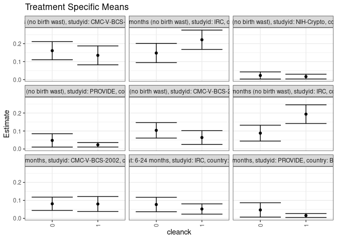

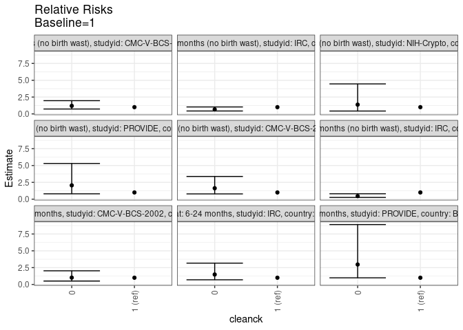

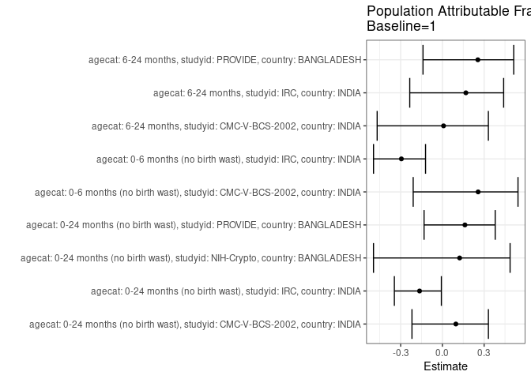

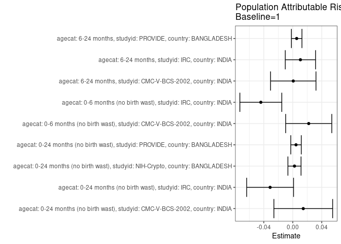

## Results Table

### Parameter: TSM

| agecat | studyid | country | intervention_level | baseline_level | estimate | ci_lower | ci_upper |
| --- | --- | --- | --- | --- | --- | --- | --- |
| 0-24 months (no birth wast) | CMC-V-BCS-2002 | INDIA | 1 | NA | 0.1349693 | 0.0824428 | 0.1874958 |
| 0-24 months (no birth wast) | CMC-V-BCS-2002 | INDIA | 0 | NA | 0.1609756 | 0.1105989 | 0.2113523 |
| 0-24 months (no birth wast) | IRC | INDIA | 1 | NA | 0.2217391 | 0.1679849 | 0.2754934 |
| 0-24 months (no birth wast) | IRC | INDIA | 0 | NA | 0.1479290 | 0.0943352 | 0.2015228 |
| 0-24 months (no birth wast) | NIH-Crypto | BANGLADESH | 1 | NA | 0.0167598 | 0.0034507 | 0.0300689 |
| 0-24 months (no birth wast) | NIH-Crypto | BANGLADESH | 0 | NA | 0.0230415 | 0.0030618 | 0.0430212 |
| 0-24 months (no birth wast) | PROVIDE | BANGLADESH | 1 | NA | 0.0231729 | 0.0107139 | 0.0356319 |
| 0-24 months (no birth wast) | PROVIDE | BANGLADESH | 0 | NA | 0.0476190 | 0.0104077 | 0.0848303 |
| 0-6 months (no birth wast) | CMC-V-BCS-2002 | INDIA | 1 | NA | 0.0636943 | 0.0254401 | 0.1019484 |
| 0-6 months (no birth wast) | CMC-V-BCS-2002 | INDIA | 0 | NA | 0.1036269 | 0.0605672 | 0.1466867 |
| 0-6 months (no birth wast) | IRC | INDIA | 1 | NA | 0.1936937 | 0.1416402 | 0.2457472 |
| 0-6 months (no birth wast) | IRC | INDIA | 0 | NA | 0.0880503 | 0.0439470 | 0.1321536 |
| 6-24 months | CMC-V-BCS-2002 | INDIA | 1 | NA | 0.0797546 | 0.0381092 | 0.1214000 |
| 6-24 months | CMC-V-BCS-2002 | INDIA | 0 | NA | 0.0809524 | 0.0440117 | 0.1178931 |
| 6-24 months | IRC | INDIA | 1 | NA | 0.0519481 | 0.0232940 | 0.0806021 |
| 6-24 months | IRC | INDIA | 0 | NA | 0.0769231 | 0.0366981 | 0.1171480 |
| 6-24 months | PROVIDE | BANGLADESH | 1 | NA | 0.0157480 | 0.0049129 | 0.0265832 |
| 6-24 months | PROVIDE | BANGLADESH | 0 | NA | 0.0467290 | 0.0067059 | 0.0867521 |

### Parameter: E(Y)

| agecat | studyid | country | intervention_level | baseline_level | estimate | ci_lower | ci_upper |
| --- | --- | --- | --- | --- | --- | --- | --- |
| 0-24 months (no birth wast) | CMC-V-BCS-2002 | INDIA | NA | NA | 0.1494565 | 0.1129794 | 0.1859337 |
| 0-24 months (no birth wast) | IRC | INDIA | NA | NA | 0.1904762 | 0.1518980 | 0.2290544 |
| 0-24 months (no birth wast) | NIH-Crypto | BANGLADESH | NA | NA | 0.0191304 | 0.0079242 | 0.0303367 |
| 0-24 months (no birth wast) | PROVIDE | BANGLADESH | NA | NA | 0.0276565 | 0.0153851 | 0.0399279 |
| 0-6 months (no birth wast) | CMC-V-BCS-2002 | INDIA | NA | NA | 0.0857143 | 0.0563444 | 0.1150842 |
| 0-6 months (no birth wast) | IRC | INDIA | NA | NA | 0.1496063 | 0.1137437 | 0.1854689 |
| 6-24 months | CMC-V-BCS-2002 | INDIA | NA | NA | 0.0804290 | 0.0527929 | 0.1080650 |
| 6-24 months | IRC | INDIA | NA | NA | 0.0625000 | 0.0387487 | 0.0862513 |
| 6-24 months | PROVIDE | BANGLADESH | NA | NA | 0.0211382 | 0.0097604 | 0.0325160 |

### Parameter: RR

| agecat | studyid | country | intervention_level | baseline_level | estimate | ci_lower | ci_upper |
| --- | --- | --- | --- | --- | --- | --- | --- |
| 0-24 months (no birth wast) | CMC-V-BCS-2002 | INDIA | 1 | 1 | 1.0000000 | 1.0000000 | 1.0000000 |
| 0-24 months (no birth wast) | CMC-V-BCS-2002 | INDIA | 0 | 1 | 1.1926829 | 0.7238395 | 1.9652043 |
| 0-24 months (no birth wast) | IRC | INDIA | 1 | 1 | 1.0000000 | 1.0000000 | 1.0000000 |
| 0-24 months (no birth wast) | IRC | INDIA | 0 | 1 | 0.6671308 | 0.4314138 | 1.0316393 |
| 0-24 months (no birth wast) | NIH-Crypto | BANGLADESH | 1 | 1 | 1.0000000 | 1.0000000 | 1.0000000 |
| 0-24 months (no birth wast) | NIH-Crypto | BANGLADESH | 0 | 1 | 1.3748080 | 0.4242272 | 4.4553890 |
| 0-24 months (no birth wast) | PROVIDE | BANGLADESH | 1 | 1 | 1.0000000 | 1.0000000 | 1.0000000 |
| 0-24 months (no birth wast) | PROVIDE | BANGLADESH | 0 | 1 | 2.0549451 | 0.7958985 | 5.3057006 |
| 0-6 months (no birth wast) | CMC-V-BCS-2002 | INDIA | 1 | 1 | 1.0000000 | 1.0000000 | 1.0000000 |
| 0-6 months (no birth wast) | CMC-V-BCS-2002 | INDIA | 0 | 1 | 1.6269430 | 0.7837857 | 3.3771267 |
| 0-6 months (no birth wast) | IRC | INDIA | 1 | 1 | 1.0000000 | 1.0000000 | 1.0000000 |
| 0-6 months (no birth wast) | IRC | INDIA | 0 | 1 | 0.4545853 | 0.2574841 | 0.8025656 |
| 6-24 months | CMC-V-BCS-2002 | INDIA | 1 | 1 | 1.0000000 | 1.0000000 | 1.0000000 |
| 6-24 months | CMC-V-BCS-2002 | INDIA | 0 | 1 | 1.0150183 | 0.5073476 | 2.0306829 |
| 6-24 months | IRC | INDIA | 1 | 1 | 1.0000000 | 1.0000000 | 1.0000000 |
| 6-24 months | IRC | INDIA | 0 | 1 | 1.4807692 | 0.6924594 | 3.1665070 |
| 6-24 months | PROVIDE | BANGLADESH | 1 | 1 | 1.0000000 | 1.0000000 | 1.0000000 |
| 6-24 months | PROVIDE | BANGLADESH | 0 | 1 | 2.9672897 | 0.9890856 | 8.9019676 |

### Parameter: PAR

| agecat | studyid | country | intervention_level | baseline_level | estimate | ci_lower | ci_upper |
| --- | --- | --- | --- | --- | --- | --- | --- |
| 0-24 months (no birth wast) | CMC-V-BCS-2002 | INDIA | 1 | NA | 0.0144872 | -0.0260772 | 0.0550516 |
| 0-24 months (no birth wast) | IRC | INDIA | 1 | NA | -0.0312629 | -0.0636129 | 0.0010870 |
| 0-24 months (no birth wast) | NIH-Crypto | BANGLADESH | 1 | NA | 0.0023707 | -0.0066927 | 0.0114340 |
| 0-24 months (no birth wast) | PROVIDE | BANGLADESH | 1 | NA | 0.0044836 | -0.0027483 | 0.0117155 |
| 0-6 months (no birth wast) | CMC-V-BCS-2002 | INDIA | 1 | NA | 0.0220200 | -0.0098094 | 0.0538494 |
| 0-6 months (no birth wast) | IRC | INDIA | 1 | NA | -0.0440874 | -0.0730371 | -0.0151377 |
| 6-24 months | CMC-V-BCS-2002 | INDIA | 1 | NA | 0.0006744 | -0.0306671 | 0.0320158 |
| 6-24 months | IRC | INDIA | 1 | NA | 0.0105519 | -0.0103493 | 0.0314532 |
| 6-24 months | PROVIDE | BANGLADESH | 1 | NA | 0.0053902 | -0.0018834 | 0.0126638 |

### Parameter: PAF

| agecat | studyid | country | intervention_level | baseline_level | estimate | ci_lower | ci_upper |
| --- | --- | --- | --- | --- | --- | --- | --- |
| 0-24 months (no birth wast) | CMC-V-BCS-2002 | INDIA | 1 | NA | 0.0969325 | -0.2187271 | 0.3308339 |
| 0-24 months (no birth wast) | IRC | INDIA | 1 | NA | -0.1641304 | -0.3452733 | -0.0073787 |
| 0-24 months (no birth wast) | NIH-Crypto | BANGLADESH | 1 | NA | 0.1239208 | -0.4952816 | 0.4867088 |
| 0-24 months (no birth wast) | PROVIDE | BANGLADESH | 1 | NA | 0.1621165 | -0.1317354 | 0.3796706 |
| 0-6 months (no birth wast) | CMC-V-BCS-2002 | INDIA | 1 | NA | 0.2569002 | -0.2099308 | 0.5436125 |
| 0-6 months (no birth wast) | IRC | INDIA | 1 | NA | -0.2946894 | -0.4951216 | -0.1211267 |
| 6-24 months | CMC-V-BCS-2002 | INDIA | 1 | NA | 0.0083845 | -0.4689453 | 0.3306072 |
| 6-24 months | IRC | INDIA | 1 | NA | 0.1688312 | -0.2346493 | 0.4404552 |
| 6-24 months | PROVIDE | BANGLADESH | 1 | NA | 0.2549970 | -0.1393521 | 0.5128551 |